# ARMA Estimation

Este Markdown Permite hacer la estimación de modelos ARMA introduciendo regresoras del tipo Dummy(con periodo corto) y Fourier(con periodo largo) para incorporar la estacionalidad antes de ver los modelos SARIMA(permite que la estacionalidad no sea dertminística sino estocásticas, es decir, puede variar sobre ele tiempo). Si la serie de tiempo presenta una tendencia, asumiremos que es una tendencia estocástica(caminata aleatoria) a menos que se modele mediante una función determinística del tiempo, la cual permite incorporar la tendencia.

# Datos de facturación minorista en millones de dólares Autralianos

```r
library(fpp3)
data(aus_retail)
aus_retail
```

| State | Industry | Series ID | Month | Turnover |
| --- | --- | --- | --- | --- |
| Australian Capital Territory | Cafes, restaurants and catering services | A3349849A | 1982 Apr | 4.4 |
| Australian Capital Territory | Cafes, restaurants and catering services | A3349849A | 1982 May | 3.4 |
| Australian Capital Territory | Cafes, restaurants and catering services | A3349849A | 1982 Jun | 3.6 |
| Australian Capital Territory | Cafes, restaurants and catering services | A3349849A | 1982 Jul | 4.0 |
| Australian Capital Territory | Cafes, restaurants and catering services | A3349849A | 1982 Aug | 3.6 |
| Australian Capital Territory | Cafes, restaurants and catering services | A3349849A | 1982 Sep | 4.2 |
| Australian Capital Territory | Cafes, restaurants and catering services | A3349849A | 1982 Oct | 4.8 |
| Australian Capital Territory | Cafes, restaurants and catering services | A3349849A | 1982 Nov | 5.4 |
| Australian Capital Territory | Cafes, restaurants and catering services | A3349849A | 1982 Dec | 6.9 |
| Australian Capital Territory | Cafes, restaurants and catering services | A3349849A | 1983 Jan | 3.8 |

[output cut: 990 more lines]

```r
?aus_retail
aus_cafe <- aus_retail %>%
  filter(
    Industry == "Cafes, restaurants and takeaway food services",
    year(Month) %in% 2004:2018
  )%>%
  summarise(Turnover = sum(Turnover))

aus_cafe
```

| Month | Turnover |
| --- | --- |
| 2004 Jan | 1895.1 |
| 2004 Feb | 1765.7 |
| 2004 Mar | 1872.8 |
| 2004 Apr | 1873.7 |
| 2004 May | 1846.0 |
| 2004 Jun | 1758.5 |
| 2004 Jul | 1878.1 |
| 2004 Aug | 1850.1 |
| 2004 Sep | 1921.5 |
| 2004 Oct | 1914.6 |

[output cut: 170 more lines]

```
Plot variable not specified, automatically selected `.vars = Turnover`
```

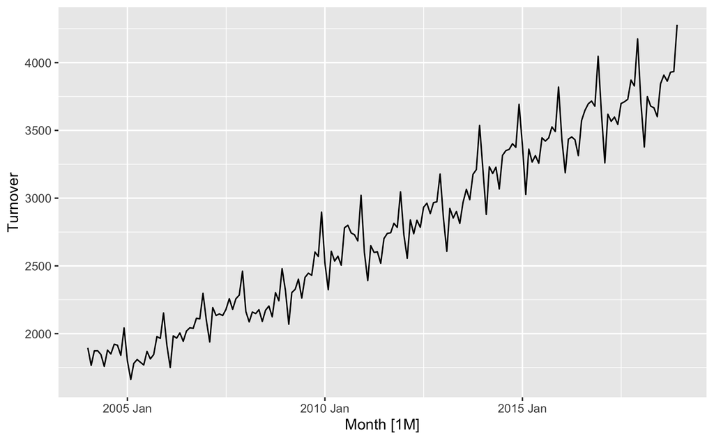

```r
aus_cafe%>%autoplot()
```

# Exploración de los datos

Note que la serie presenta una varianza creciente. Parece tener estacionalidad y tendencia. Veamos algunas exploraciones acerca de esta serie.

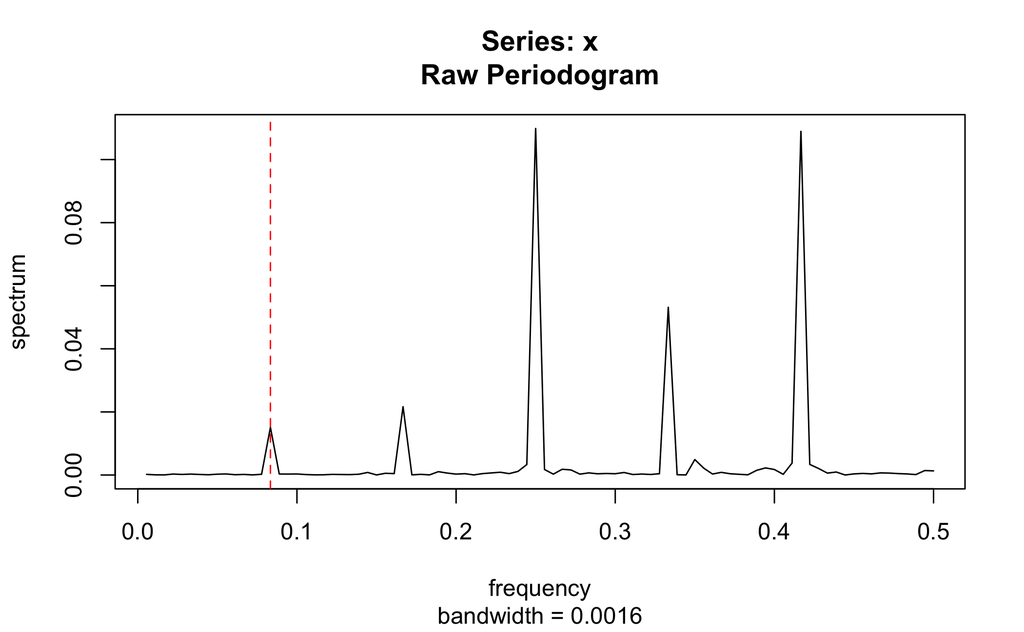

Note que en efecto hay una estacionalidad de periodo $s=12$.

# Modelamiento del ciclo para la serie diferenciada y transformación logarítmica

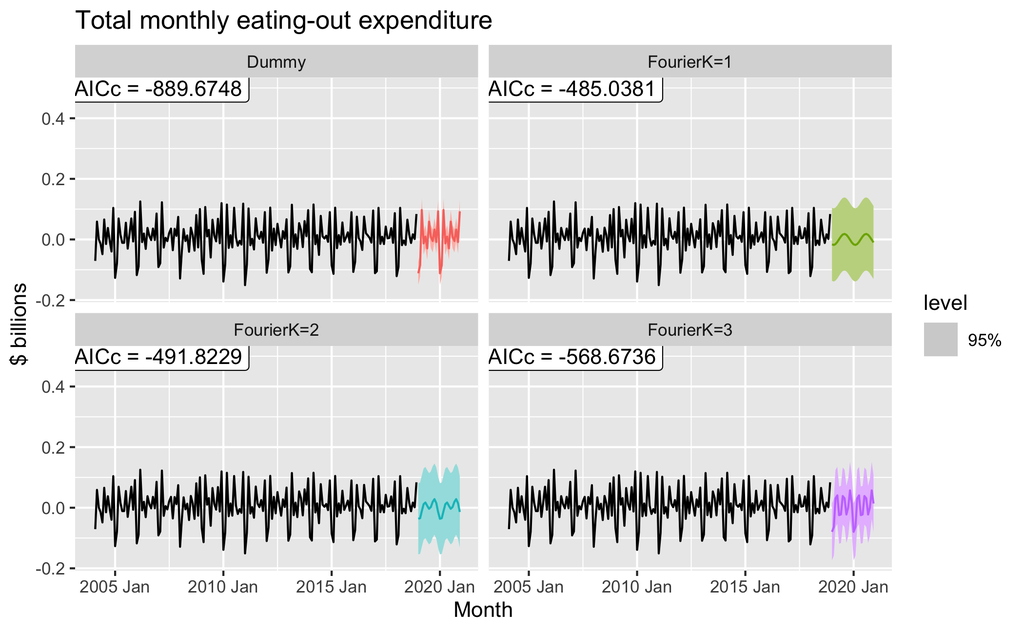

# Análisis de Residuales

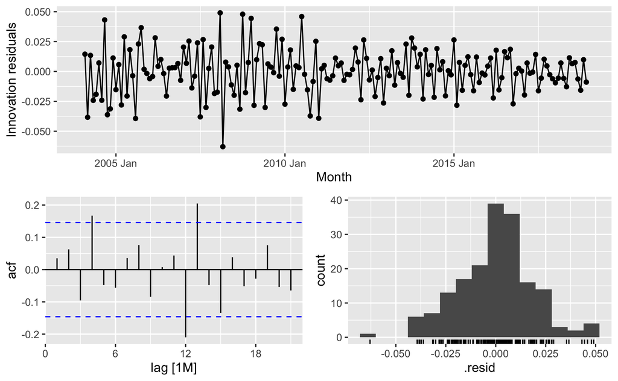

# Análisis de Residuales(complemento)

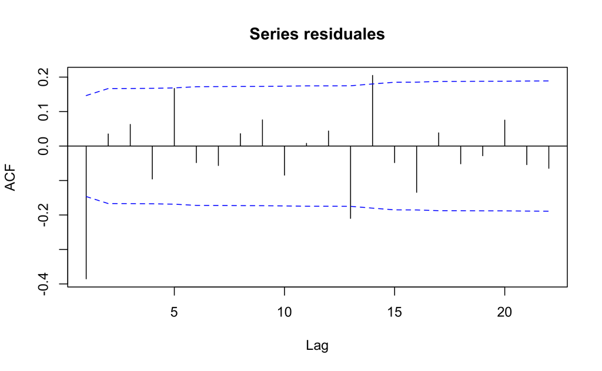

Viendo el ajuste del modelo, parece que hay que ajustarle un modelo MA(1) o AR(1), basado en el análisis de resultados.

Tarea(Chequear los residuales de los otroas modelos) ### Reajuste del modelo

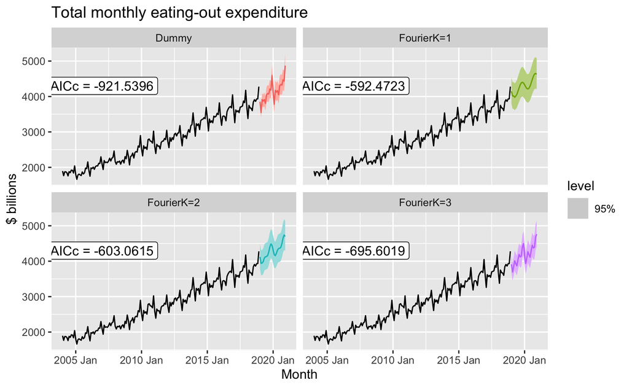

# Análisis de Residuales Modelos Finales

```r
##Chequeo significancia

ajuste_final %>%
  select(Dummy)%>%report()
```

```
Series: Turnover
Model: LM w/ ARIMA(1,0,1) errors
Transformation: log(Turnover)

Coefficients:
         ar1      ma1  trend()  season()year2  season()year3  season()year4  season()year5  season()year6
      0.9389  -0.3610   0.0043        -0.0892         0.0041        -0.0129        -0.0075        -0.0409
s.e.  0.0312   0.0698   0.0002         0.0047         0.0053         0.0057         0.0060         0.0062
      season()year7  season()year8  season()year9  season()year10  season()year11  season()year12
             0.0138         0.0189         0.0097          0.0384          0.0260          0.1149
s.e.         0.0063         0.0062         0.0061          0.0058          0.0054          0.0048
      intercept
         7.4972
s.e.     0.0240

sigma^2 estimated as 0.0003113:  log likelihood=478.44
AIC=-924.88   AICc=-921.54   BIC=-873.79
```

```r
ajuste_final %>%
     select(Dummy)%>%coef()
```

| .model | term | estimate | std.error | statistic | p.value |
| --- | --- | --- | --- | --- | --- |
| Dummy | ar1 | 0.938924988 | 0.0312072259 | 30.0867816 | 3.897038e-72 |
| Dummy | ma1 | -0.361013364 | 0.0697782989 | -5.1737198 | 6.081203e-07 |
| Dummy | trend() | 0.004332977 | 0.0002348821 | 18.4474546 | 2.375078e-43 |
| Dummy | season()year2 | -0.089181800 | 0.0047068711 | -18.9471517 | 9.833129e-45 |
| Dummy | season()year3 | 0.004063060 | 0.0053177008 | 0.7640633 | 4.458299e-01 |
| Dummy | season()year4 | -0.012893974 | 0.0057474413 | -2.2434286 | 2.608832e-02 |
| Dummy | season()year5 | -0.007537969 | 0.0060369835 | -1.2486317 | 2.134214e-01 |
| Dummy | season()year6 | -0.040918418 | 0.0062073712 | -6.5919077 | 4.651849e-10 |
| Dummy | season()year7 | 0.013802389 | 0.0062691053 | 2.2016522 | 2.896125e-02 |
| Dummy | season()year8 | 0.018943495 | 0.0062255375 | 3.0428690 | 2.694134e-03 |

[output cut: 5 more lines]

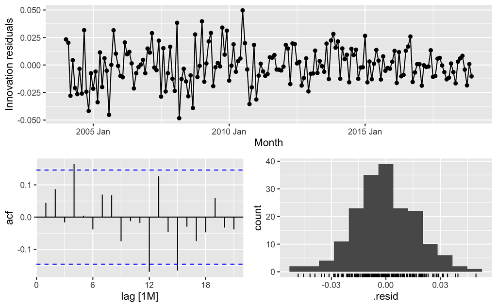

```r
###Residuales
ajuste_final %>%
  select(Dummy) %>%
  gg_tsresiduals()
```

```r
####Saca algunas carcaterística para comprobar el ajuste del modelo

augment_ajuste_final_tb<-ajuste_final %>%
    select(Dummy)%>%augment()
```

# Análisis de Residuales(complemento)

| .model | Month | Turnover | .fitted | .resid | .innov |
| --- | --- | --- | --- | --- | --- |
| Dummy | 2004 Jan | 1895.1 | 1851.502 | 43.5977387 | 0.0232742649 |
| Dummy | 2004 Feb | 1765.7 | 1730.304 | 35.3955057 | 0.0202498110 |
| Dummy | 2004 Mar | 1872.8 | 1925.802 | -53.0021869 | -0.0279079642 |
| Dummy | 2004 Apr | 1873.7 | 1865.546 | 8.1539346 | 0.0043612789 |
| Dummy | 2004 May | 1846.0 | 1885.043 | -39.0425313 | -0.0209292476 |
| Dummy | 2004 Jun | 1758.5 | 1805.706 | -47.2055351 | -0.0264902207 |
| Dummy | 2004 Jul | 1878.1 | 1884.557 | -6.4572788 | -0.0034323005 |
| Dummy | 2004 Aug | 1850.1 | 1898.714 | -48.6135726 | -0.0259368981 |
| Dummy | 2004 Sep | 1921.5 | 1861.564 | 59.9363528 | 0.0316893259 |
| Dummy | 2004 Oct | 1914.6 | 1961.597 | -46.9967483 | -0.0242500856 |

[output cut: 170 more lines]

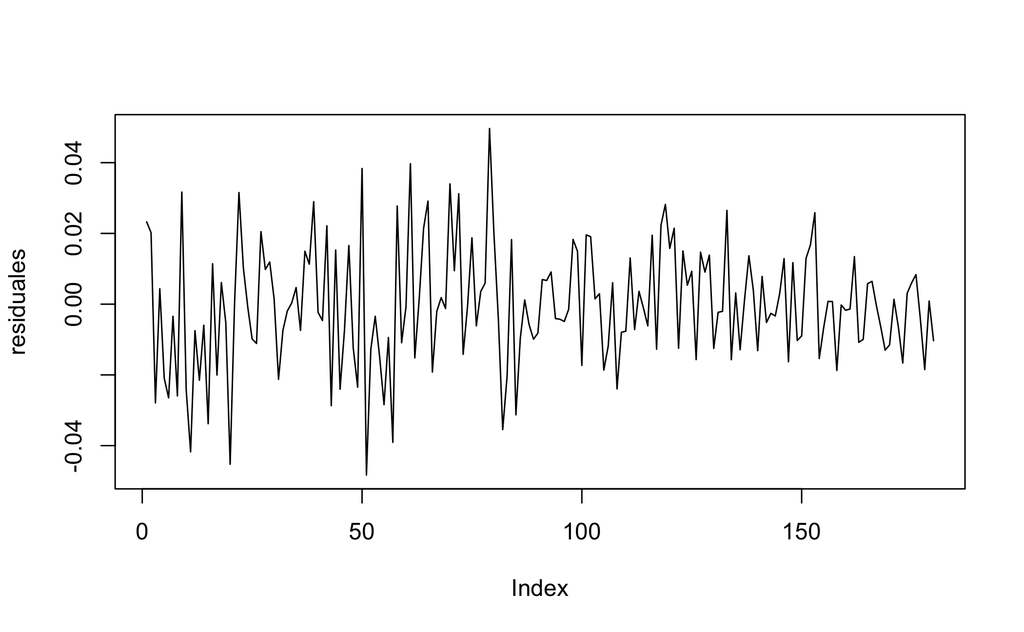

```r
augment_ajuste_final_tb


residuales=na.omit(augment_ajuste_final_tb$.innov)
plot(residuales,type="l")
```

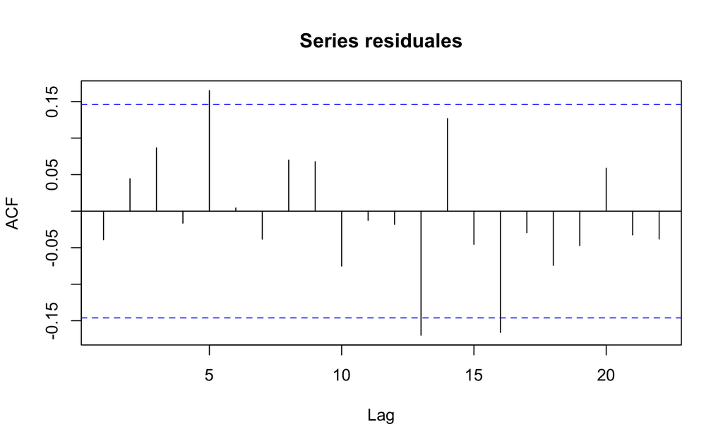

```r
acf(residuales)
```

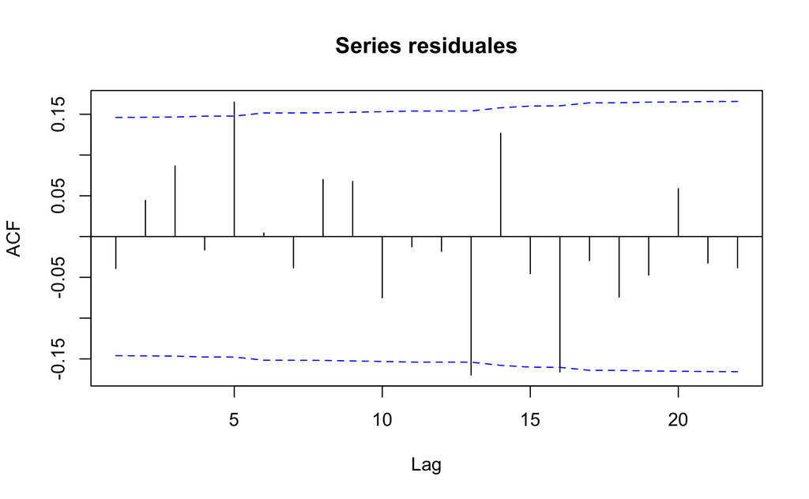

```r
acf(residuales,ci.type="ma")
```

```r
ajuste_final %>%select(Dummy)%>%
  forecast(h = "2 years") %>%
  autoplot(aus_cafe, level = 95)

cafe_pronostico<-ajuste_final %>%select(Dummy)%>%fabletools::forecast(h="2 years")
cafe_pronostico


IP<-cafe_pronostico%>%hilo(level=c(80,95))
IP$`80%`
IP$`95%`
```

[output not shown]

Tarea: Hacer una análisis similar con los otros modelos. Adicionalmente, ingresar a https://otexts.com/fpp3/training-test.html, para ver como se calcula el ECM de predicción un paso adelante de una forma muy sencialla.